# HW5

### Exercise 1:

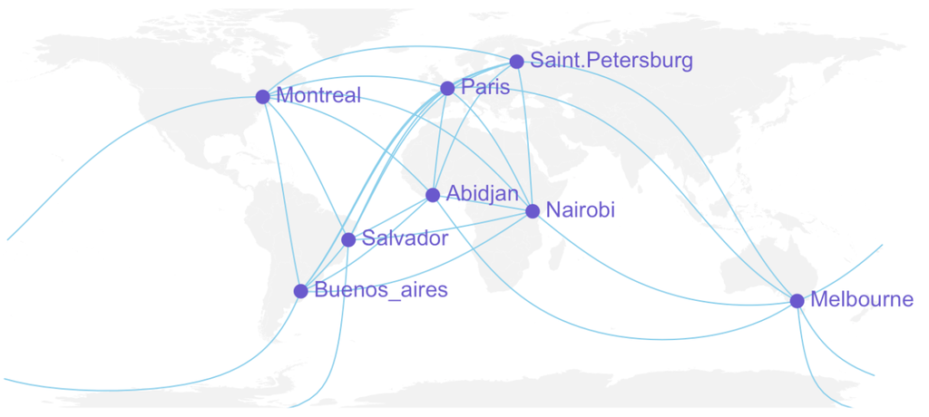

source: https://r-graph-gallery.com/how-to-draw-connecting-routes-on-map-with-r-and-great-circles.html

**Marks**: Dots, connection lines, and city names (labels).

**Properties**:

- Position (X,Y) on the map - mapped to each city.
- Color - each label is purple and each line is blue.
- Connection lines - mapped to the relationships between the cities.

**Main Story** **Of This Graphic**: This visualization displays connections between big cities worldwide. It shows how certain locations act as hubs connecting various regions.

**What Makes it a Good Graphic**:

- Easy/clear to understand the relationships
- Accurate representation of the world
- Colors: contrasts nicely, and minimalistic

**Features I think I would be able to implement:**

- Importing the `map` package to use the `maps()` function
- Using the `points()` function to add dots to the map
- Importing the `geosphere` package using the `lines()` function to display the lines between cities

**Features I would not know how to do:**

- Finding out the longitude and latitude of the cities and creating a dataframe to store those
- Using the `gcIntermediate()` function to make connections between cities

### Exercise 2:

Exercise 1:

```r
library(tidyverse)
seattle_weather <- read_csv("weather-with-dates.csv")
weather_2023 <- seattle_weather %>%
  filter(lubridate::year(date) == 2014 & month(date) == 3)
```

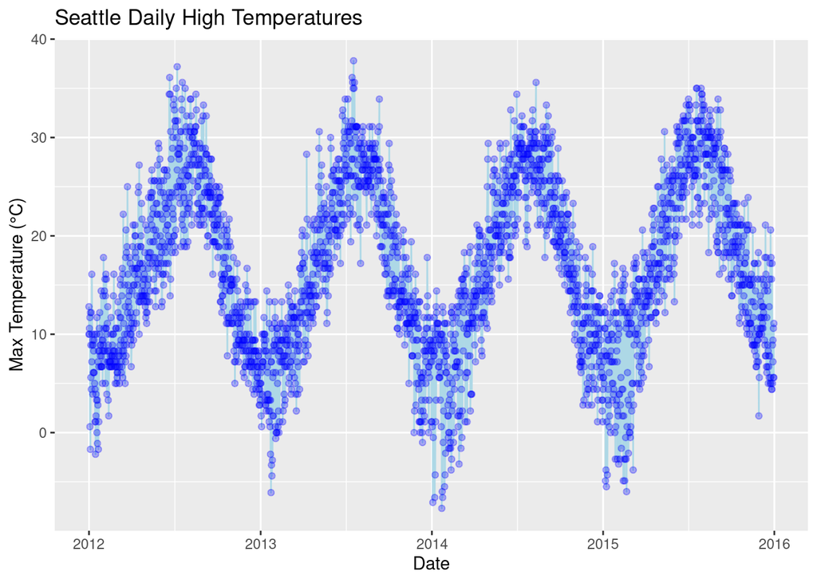

```r
ggplot(seattle_weather, aes(x = date, y = temp_max)) +
  geom_line(color = "lightblue") +
  geom_point(color = "blue", alpha = 0.3) +
  labs(title = "Seattle Daily High Temperatures",
       x = "Date",
       y = "Max Temperature (°C)")
```

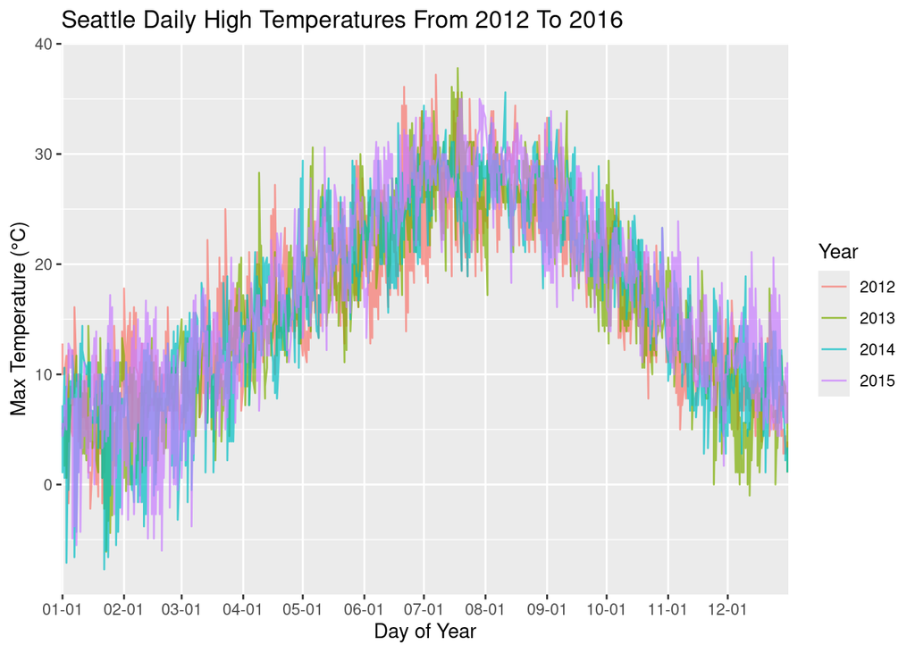

```r
# Create a day-of-year column for overlaying same days across years
seattle_weather$day_of_year <- format(seattle_weather$date, "%m-%d")

# Define the breaks (first day of each month)
month_breaks <- c("01-01", "02-01", "03-01", "04-01", "05-01", "06-01",
                  "07-01", "08-01", "09-01", "10-01", "11-01", "12-01")

ggplot(seattle_weather, aes(x = day_of_year, y = temp_max, group = year, color = as.factor(year))) +
  geom_line(alpha = 0.7) +
  labs(title = "Seattle Daily High Temperatures From 2012 To 2016",
       x = "Day of Year",
       y = "Max Temperature (°C)",
       color = "Year") +
    scale_x_discrete(breaks = month_breaks)
```

Exercise 2:

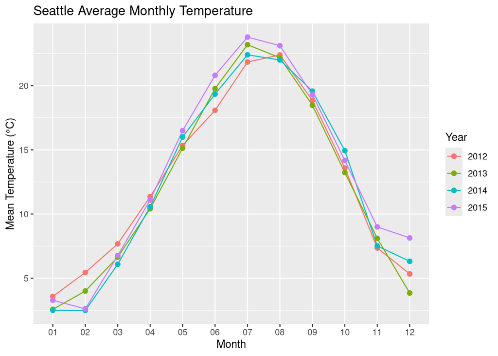

```r
# Extract year and month
seattle_weather$month <- format(seattle_weather$date, "%m")

# Compute mean temperature (average of temp_max and temp_min) for each month and year
seattle_weather$mean_temp <- (seattle_weather$temp_max + seattle_weather$temp_min) / 2
monthly_avg <- aggregate(mean_temp ~ year + month, seattle_weather, mean)

ggplot(monthly_avg, aes(x = month, y = mean_temp, group = year, color = as.factor(year))) +
  geom_line() +
  geom_point(size=2) +
  labs(title = "Seattle Average Monthly Temperature",
       x = "Month",
       y = "Mean Temperature (°C)",
       color = "Year")
```